# Incidence prediction

Maximilian Knoll

2019-01-03

# Overview

This vignette demonstrates the use of the incAnalysis package for the comparative evaluation of model performance for incidence prediction. However, the following approach can be used not only for incidence data but for any kind of rates.

# Requirements and installation

## INLA

The package relies on the INLA framework for GLMs and BAPC models. It can be obtained from http://www.r-inla.org/download.

```r
install.packages("INLA", repos=c(getOption("repos"), INLA="https://inla.r-inla-download.org/R/stable"), dep=TRUE)
```

## BAPC

The BAPC package (Riebler2017) is available on R-Forge (https://r-forge.r-project.org/projects/bapc/)

```r
install.packages("BAPC", repos="http://R-Forge.R-project.org")
```

## incAnalysis

This package can be easily installed via devtools from github.

```r
if (!any(grepl("devtools", installed.packages()))) {
    install.packages("devtools")
}
devtools::install_github("mknoll/incAnalysis")
```

# Included data

The following cancer registry incidence data, split by gender, are included in the package for selected entities as counts (see below):

- SEER9 data, 1973-2014
- NORDCAN data, all Nordic countries (retreived: October 2018)
- Saarland data (retrieved: October 2018)

Corresponding population data (counts), split by gender, is included as well:

- SEER9: all race population data dived by 1000
- NORDCAN data, all Nordic countries
- Saarland data

# Analysis of GBM incidence data

The analysis workflow will be demonstrated using Glioblastoma multiforme (GBM) incidences from the SEER9 dataset for males aged >= 20. Corresponding analyses for NORDCAN and Saarland data are added as non-executed chunks.

```r
dataset <- "SEER9" #NORDCAN, Saarland
gender <- "MALE" #FEMALE
entity <- "Glioblastoma"
ageLow <- 20 # exclude data for ages below 20
```

## Population data

Population data is named after an equal scheme, thus loading different datasets works by adjusting the dataset variable.

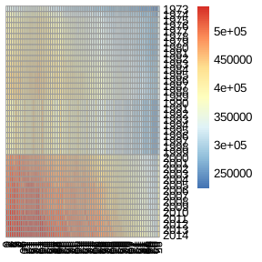

```r
#filename
fn <- paste("population_", dataset, "_", gender, ".csv", sep="")
population <- read.csv(system.file("extdata", fn, package="incAnalysis"), check.names=F, row.names=1)

#multiply by factor 1000 to get actual counts (only SEER9 data!)
if (dataset == "SEER9") {
    population <- population*1000
}

#visualize population as heatmap
require(pheatmap)
pheatmap(population, cluster_rows=F, cluster_cols=F)
```

```r
# age/ age categories
rownames(population)
```

```
#>  [1] "1973" "1974" "1975" "1976" "1977" "1978" "1979" "1980" "1981" "1982"
#> [11] "1983" "1984" "1985" "1986" "1987" "1988" "1989" "1990" "1991" "1992"
#> [21] "1993" "1994" "1995" "1996" "1997" "1998" "1999" "2000" "2001" "2002"
#> [31] "2003" "2004" "2005" "2006" "2007" "2008" "2009" "2010" "2011" "2012"
#> [41] "2013" "2014"
```

```r
#adjust population matrix rownames
if (dataset == "Saarland") {
    rownames(population) <- do.call(rbind, strsplit(trimws(rownames(population)), " "))[,1]
    rownames(population)[1] <- 0
    population <- data.frame(t(population), check.names=F)
} else if (dataset == "NORDCAN") {
    rownames(population) <- do.call(rbind, strsplit(rownames(population), "-"))[,1]
    population <- data.frame(t(population), check.names=F)
}

population[1:4,1:10]
```

```
#>           0      1      2      3      4      5      6      7      8      9
#> 1973 336000 337000 341000 344000 335000 327000 334000 346000 332000 346000
#> 1974 374000 375000 378000 378000 380000 363000 367000 377000 364000 374000
#> 1975 403000 384000 392000 393000 397000 385000 393000 402000 396000 401000
#> 1976 407000 389000 394000 400000 399000 395000 389000 405000 399000 404000
```

## Incidence data SEER9

SEER9 data were preprocessed manually and only selected entities are included.

```r
#filename
fn <- paste(dataset, "_", entity ,"_", gender, ".csv", sep="")
incidence <- data.matrix(read.csv(system.file("extdata", fn, package="incAnalysis"), check.names=F, row.names=1))

## additionally included entities
fl <- list.files(system.file("extdata", "/", package="incAnalysis"))
fl[which(grepl("SEER9", fl))]
```

```
#>  [1] "population_SEER9_FEMALE.csv"      "population_SEER9_MALE.csv"
#>  [3] "SEER9_Glioblastoma_FEMALE.csv"    "SEER9_Glioblastoma_MALE.csv"
#>  [5] "SEER9_Kolorektal_FEMALE.csv"      "SEER9_Kolorektal_MALE.csv"
#>  [7] "SEER9_Lunge_Bronchial_FEMALE.csv" "SEER9_Lunge_Bronchial_MALE.csv"
#>  [9] "SEER9_Mamma_FEMALE.csv"           "SEER9_Mamma_MALE.csv"
#> [11] "SEER9_Melanome_FEMALE.csv"        "SEER9_Melanome_MALE.csv"
#> [13] "SEER9_Nierentumore_FEMALE.csv"    "SEER9_Nierentumore_MALE.csv"
#> [15] "SEER9_Prostata_MALE.csv"
```

## Incidence data (NORDCAN)

NORDCAN data was acquired via webscraping (all available entities).

```r
dataset <- "NORDCAN"
load(system.file("extdata", paste(dataset, "_incidence_", gender,sep=""), package="incAnalysis")) #coll
names(coll) <-  unlist(lapply(coll, function(x) x$meta$Name))

#Entities
names(coll)

incidence <- data.matrix(t(coll[which(names(coll) == "Brain, central nervous system")][[1]]$data))
colnames(incidence) <- colnames(population)
```

## Incidence data (Saarland)

Saarland data was acquired via webscraping (all available entities).

```r
dataset <- "Saarland"
load(system.file("extdata", paste(dataset, "_incidence_", gender,sep=""), package="incAnalysis")) #all
nm <- lapply(all, function(x) x$map$Tumor)
names(all) <- unlist(nm)

#Entities
names(all)

incidence <- data.matrix(t(all[which(names(all) == "191 Gehirn")][[1]]$data[,]))

## differentially groups in population and incidence -> remove 85+ (incidence) and 85/90 (population)
population <- population[,1:17]
incidence <- incidence[,1:17]
colnames(incidence) <- colnames(population)
```

## Visualize incidence and correct NAs

```r
# NA correspond to 0 values
incidence[which(is.na(incidence))] <- 0
incidence <- data.frame(incidence, check.names=F)

incidence[1:4,1:10]
```

```
#>      0 1 2 3 4 5 6 7 8 9
#> 1973 0 0 0 0 0 0 0 0 0 0
#> 1974 0 1 0 0 1 1 1 0 0 0
#> 1975 0 0 1 0 0 0 2 0 0 1
#> 1976 0 0 0 0 0 0 0 0 0 1
```

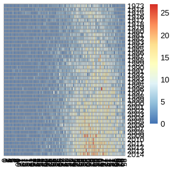

```r
#visualize incidence as heatmap
pheatmap(incidence, cluster_rows=F, cluster_cols=F)
```

## Remove childhood cancers

For further analyses, only cancers in persons ages >= ageLow are analyzed.

```r
# get ages from colnames
ages <- as.numeric(gsub("+", "", as.character(colnames(incidence))))
w <- which(ages >= ageLow)

incidence <- incidence[,w]
population <- population[,w]
```

## Create incAnalysis object

```r
require(incAnalysis)
obj <- new("incClass",
       population=population,
       cases=incidence,
       nPred=10, #prediction period: 10 years
       nFit=5, #fitting period
       predLast=0, #only retrieve data for last prediction year
       gridFactor=1, #width of age and year bins. 1 for SEER data, 5 for NORDCAN and Saarland
       entity=entity)
```

## Forward Projection of Last observations

```r
obj <- runFwProj(obj, ci="W") #Wilson, ci can be PC for Pearson Clopper
```

## GLMs

Fitted using INLA.

```r
# linear model with age and period effects
frm <- as.formula(Y~offset(log(N))+ PERIOD + AGE)
# use neg-binomial distribution
obj <- runGLM(obj, frm=frm, family="nbinomial", text="arbitrary model ID 1")
```

## Splines with INLA

```r
### RW2
frm <- as.formula(Y~offset(log(N))+PERIOD+f(inla.group(AGE), model="rw2"))
obj <- runGLM(obj, frm=frm, family="nbinomial", text="rw2")

### Cubic spline
ZSplineAge <- createZSpline(obj@dataLong$AGE, nKnots=10)
frm <- as.formula(Y~offset(log(N))+PERIOD+AGE+f(SEQNO,model="z",Z=ZSplineAge))
obj <- runGLM(obj, frm=frm, family="poisson", text="splineAge")
```

## GAMs

```r
# multivariate smooths (tensor spline)
frm <- as.formula(Y~offset(log(N))+ te(PERIOD, AGE))
# use Poisson distribution
obj <- runGAM(obj, frm=frm, family="poisson", text="arbitrary model ID 2")
```

## BAPC

```r
obj <- runBAPC(obj)
```

## PIT Histograms

For INLA based analyses

```r
pitHist(obj)
```

[output not shown]

## Calcuate bias, precision, coverage

```r
obj <- evaluate(obj)
```

```
#> [1] "###########"
#> [1] "FWDPROJ"
#> [1] "###########"
#> [1] "GLM"
#> [1] "###########"
#> [1] "GLM"
#> [1] "###########"
#> [1] "GLM"
#> [1] "###########"
#> [1] "GAM"
#> [1] "###########"
#> [1] "BAPC"
```

## Extract metrics

```r
df <- metrics(obj)
df
```

```
#>            SD       CVG          BIAS N_NA_PRED N_NA_Y    TYPE
#> 1  0.01089754 0.9696970  0.000000e+00         0      0 FWDPROJ
#> 2  0.01037772 0.9848485  0.000000e+00         0      0 FWDPROJ
#> 3  0.01091728 0.9848485  0.000000e+00         0      0 FWDPROJ
#> 4  0.01092511 0.9848485  0.000000e+00         0      0 FWDPROJ
#> 5  0.01149028 0.9848485  0.000000e+00         0      0 FWDPROJ
#> 6  0.01138030 0.8484848  3.209156e-03         0      0 FWDPROJ
#> 7  0.01133193 0.8181818 -7.925895e-02         0      0 FWDPROJ
#> 8  0.01130024 0.8030303  1.778563e-02         0      0 FWDPROJ
#> 9  0.01132320 0.7878788 -2.894026e-02         0      0 FWDPROJ
#> 10 0.01131808 0.7575758 -2.890679e-02         0      0 FWDPROJ
#> 11 0.01118268 0.7272727 -2.919028e-02         0      0 FWDPROJ
#> 12 0.01113636 0.8181818  3.877727e-02         0      0 FWDPROJ
#> 13 0.01108162 0.7575758  2.761878e-02         0      0 FWDPROJ
#> 14 0.01105522 0.7878788  8.210476e-03         0      0 FWDPROJ
```

[output cut: 167 more lines]

## Plot data

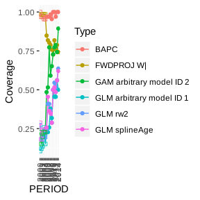

```r
require(ggplot2)
df$COL <- ifelse(as.numeric(as.character(df$PERIOD)) <= 2004, 0, 19)

# Coverage
ggplot(df, aes(x=PERIOD, y=CVG, group=paste(TYPE, TEXT), color=paste(TYPE, TEXT))) + geom_line() + geom_point(shape=df$COL) + labs(color="Type", y="Coverage") + ggpubr::rotate_x_text()
```

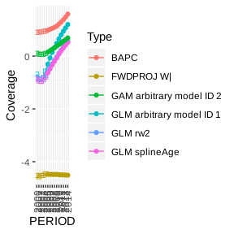

```r
# Precision
ggplot(df, aes(x=PERIOD, y=log(SD), group=paste(TYPE, TEXT), color=paste(TYPE, TEXT))) + geom_line() + geom_point(shape=df$COL) + labs(color="Type", y="Coverage") + ggpubr::rotate_x_text()
```

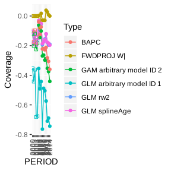

```r
# Bias
#negative values -> Overestimation
ggplot(df, aes(x=PERIOD, y=BIAS, group=paste(TYPE, TEXT), color=paste(TYPE, TEXT))) + geom_line() + geom_point(shape=df$COL) + labs(color="Type", y="Coverage") + ggpubr::rotate_x_text()
```

## Calculate and plot scores

Lowe scores correspond to better performance for all three analyzed metrics.

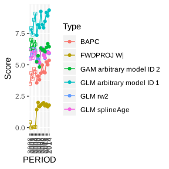

```r
#calcuate score
scr <- scaleAggMetr(bias=df$BIAS, sd=df$SD, cvg=df$CVG, plot=F)

df$SCORE <- scr$VAL
#Plot score
ggplot(df, aes(x=PERIOD, y=SCORE, group=paste(TYPE, TEXT), color=paste(TYPE, TEXT))) + geom_line() + geom_point(shape=df$COL) + labs(color="Type", y="Score") + ggpubr::rotate_x_text()
```

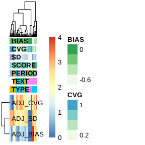

```r
#HEatmap of adjusted metrics
df$ADJ_CVG <- scr$MAT[,"CVG"]
df$ADJ_SD <- scr$MAT[,"SD"]
df$ADJ_BIAS <- scr$MAT[,"BIAS"]

sub <- t(df[,which(grepl("ADJ_", colnames(df)))])
colnames(sub) <- paste("RN", 1:length(sub[1,]))
rownames(df) <- colnames(sub)
pheatmap(sub, annotation_col=df[,c("TYPE", "TEXT", "PERIOD", "SCORE", "SD", "CVG", "BIAS")], show_colnames=F)
```